# Lab4 part 2

2022-10-12

# Linear Regression and Correlation

For this practrice, we will use the following dataset:

```r
df <- read.csv("birthweight.csv", sep = ";")
head(df)
```

```
##     bw bpd  ad idnr
## 1 2350  88  92    1
## 2 2450  91  98    2
## 3 3300  94 110    3
## 4 1800  84  89    4
## 5 2900  89  97    5
## 6 3500 100 110    6
```

Let’s explore the data, numerically and graphically:

```r
summary(df)
```

```
##        bw            bpd               ad             idnr
##  Min.   :1150   Min.   : 64.00   Min.   : 71.0   Min.   :  1.0
##  1st Qu.:2400   1st Qu.: 88.00   1st Qu.: 96.0   1st Qu.: 27.5
##  Median :2800   Median : 91.00   Median :103.0   Median : 54.0
##  Mean   :2739   Mean   : 89.48   Mean   :101.7   Mean   : 54.0
##  3rd Qu.:3125   3rd Qu.: 93.00   3rd Qu.:108.0   3rd Qu.: 80.5
##  Max.   :4850   Max.   :100.00   Max.   :133.0   Max.   :107.0
```

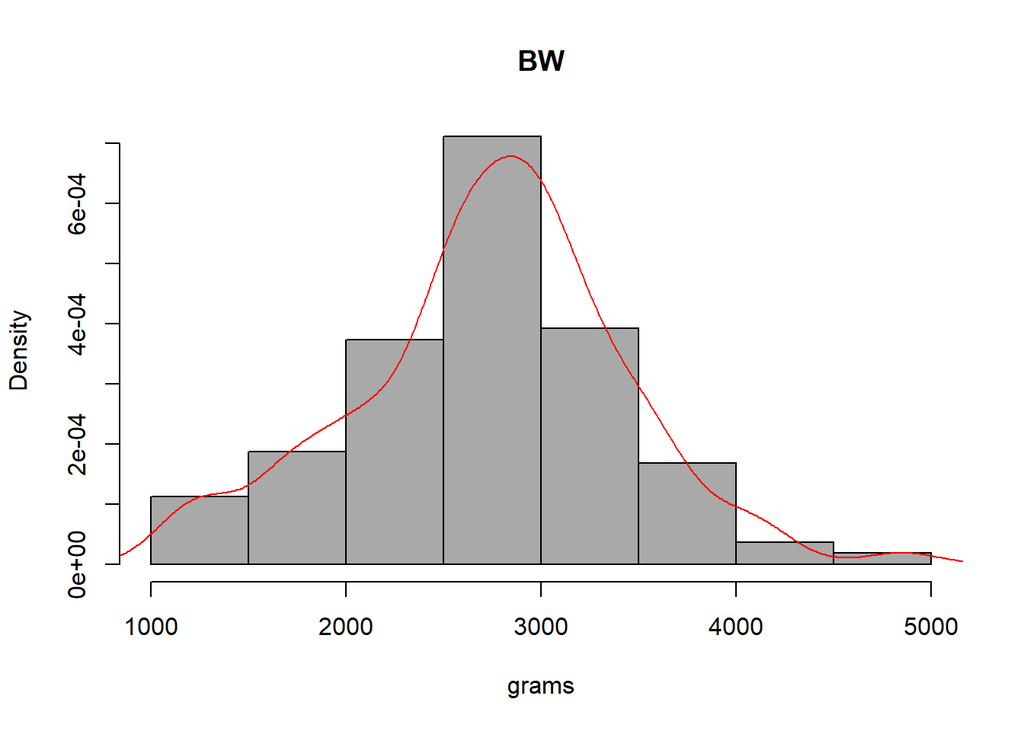

```r
hist(df$bw,
     main="BW",
     xlab="grams",
     col="darkgray",
     prob = TRUE
     )
lines(density(df$bw), col = "red")
```

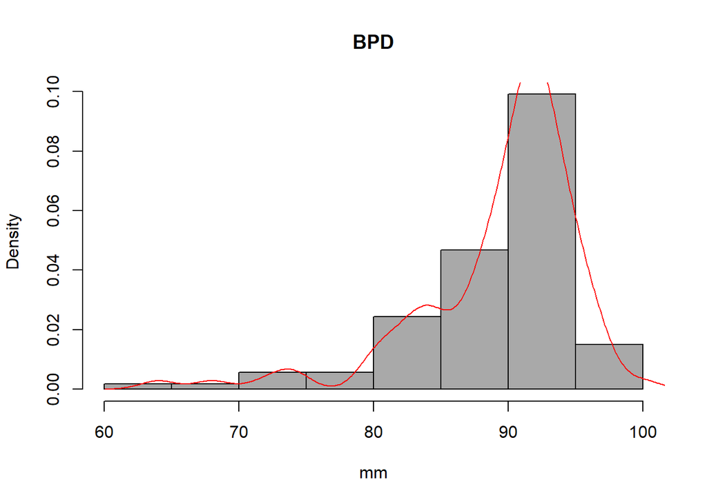

```r
hist(df$bpd,
     main="BPD",
     xlab="mm",
     col="darkgray",
     prob = TRUE
     )
lines(density(df$bpd), col = "red")
```

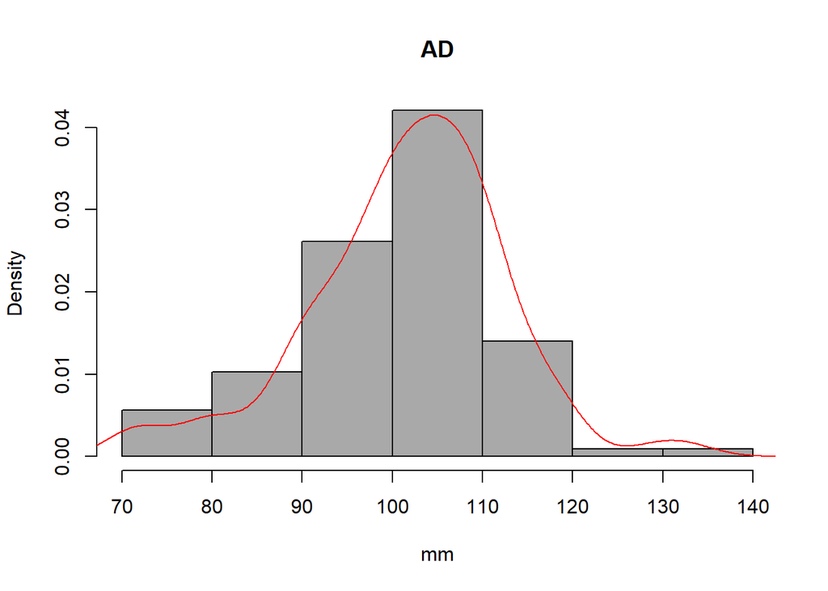

```r
hist(df$ad,
     main="AD",
     xlab="mm",
     col="darkgray",
     prob = TRUE
     )
lines(density(df$ad), col = "red")
```

Let’s also check for normality:

```r
shapiro.test(df$bw)
```

```
##
##  Shapiro-Wilk normality test
##
## data:  df$bw
## W = 0.98412, p-value = 0.2329
```

```r
shapiro.test(df$bpd)
```

```
##
##  Shapiro-Wilk normality test
##
## data:  df$bpd
## W = 0.85023, p-value = 5.15e-09
```

```r
shapiro.test(df$ad)
```

```
##
##  Shapiro-Wilk normality test
##
## data:  df$ad
## W = 0.9716, p-value = 0.0215
```

Now, let’s check correlation among variables:

```r
cor(df$bw, df$bpd)
```

```
## [1] 0.7980023
```

```r
cor(df$bw, df$ad)
```

```
## [1] 0.8730657
```

```r
cor(df$ad, df$bpd)
```

```
## [1] 0.7564475
```

As seen, the highest correlation seems to be between bw and ad. Let’s see the graphs:

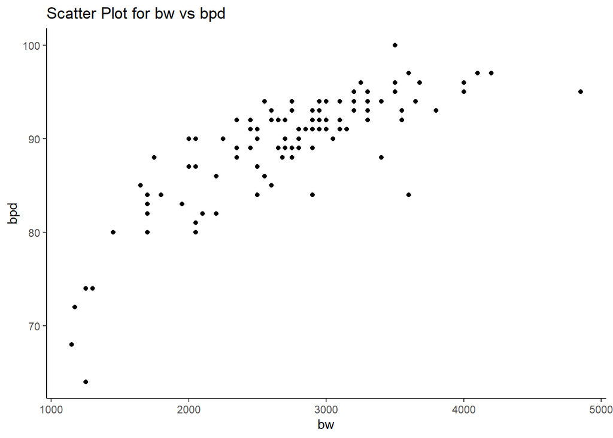

```r
library(ggplot2)

ggplot(data=df, aes(x=bw, y=bpd)) + geom_point() + theme_classic() +
  ggtitle("Scatter Plot for bw vs bpd")
```

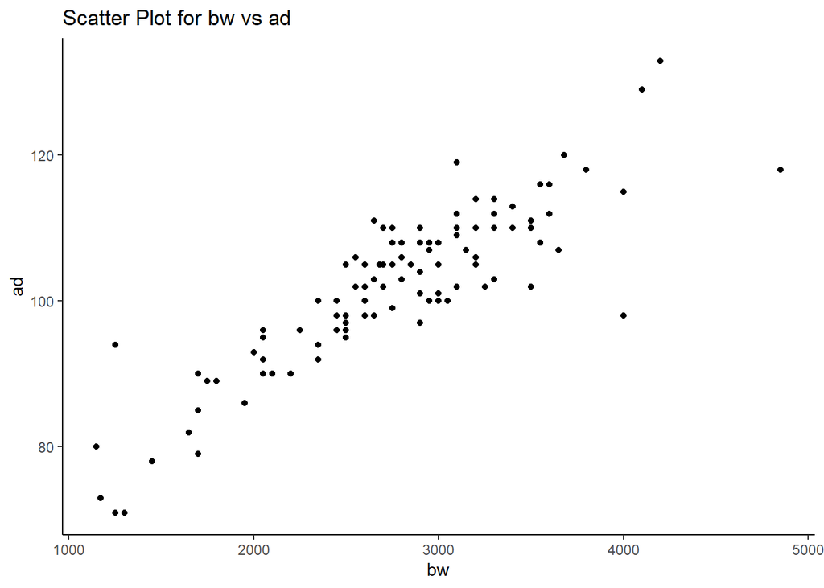

```r
library(ggplot2)

ggplot(data=df, aes(x=bw, y=ad)) + geom_point() + theme_classic() +
  ggtitle("Scatter Plot for bw vs ad")
```

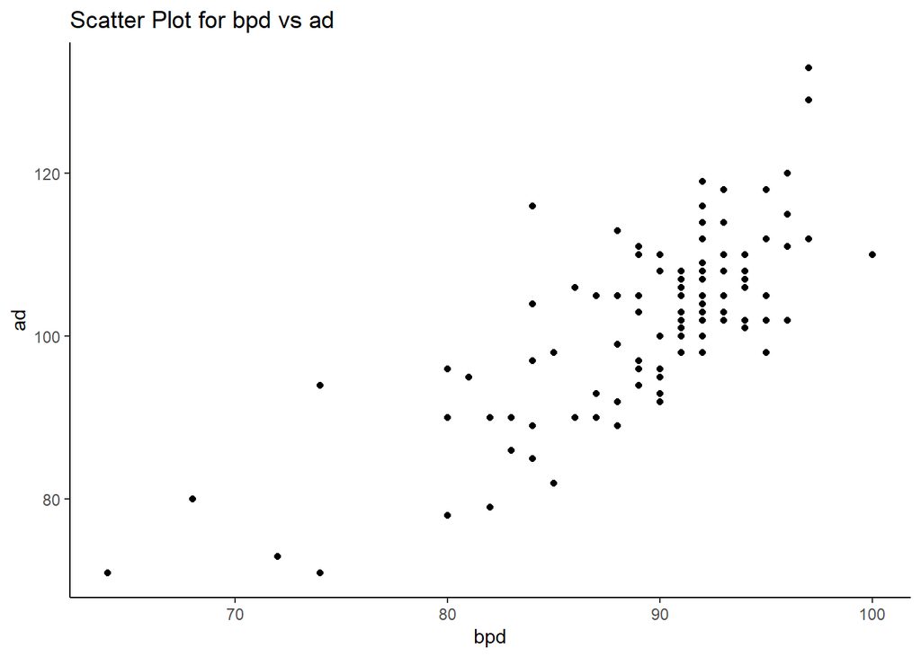

```r
library(ggplot2)

ggplot(data=df, aes(x=bpd, y=ad)) + geom_point() + theme_classic() +
  ggtitle("Scatter Plot for bpd vs ad")
```

Let’s now build a regression model having BW as the dependent variable and BPD as the explanatory variable:

```r
baby.lm<-lm(df$bw~df$bpd, data=df)
baby.lm
```

```
##
## Call:
## lm(formula = df$bw ~ df$bpd, data = df)
##
## Coefficients:
## (Intercept)       df$bpd
##    -5505.41        92.14
```

```r
summary(baby.lm)
```

```
##
## Call:
## lm(formula = df$bw ~ df$bpd, data = df)
##
## Residuals:
##     Min      1Q  Median      3Q     Max
## -853.03 -287.32  -10.89  163.76 1601.98
##
## Coefficients:
##              Estimate Std. Error t value Pr(>|t|)
## (Intercept) -5505.406    608.965  -9.041 8.67e-15 ***
## df$bpd         92.141      6.791  13.568  < 2e-16 ***
## ---
## Signif. codes:  0 '***' 0.001 '**' 0.01 '*' 0.05 '.' 0.1 ' ' 1
##
## Residual standard error: 418 on 105 degrees of freedom
## Multiple R-squared:  0.6368, Adjusted R-squared:  0.6333
## F-statistic: 184.1 on 1 and 105 DF,  p-value: < 2.2e-16
```

Both coefficients (BW and BPD) are significant, as their p-values are really small. Also, 0.63 of the variance is explained by the model.

The relationship between the bw and the bpd is such that for every increase in bpd of 1mm - the bw increases by 92.14g.

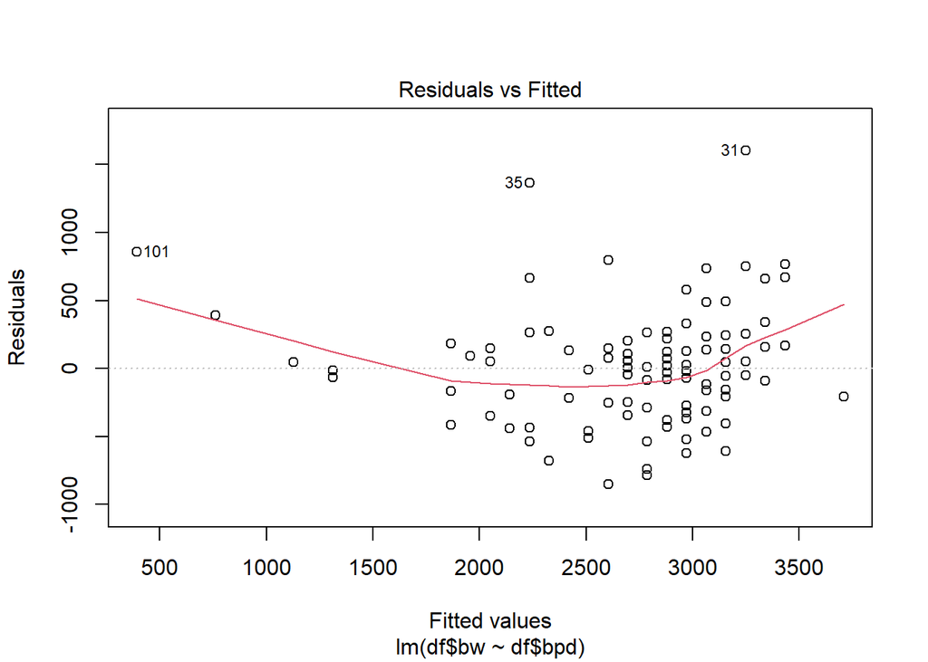

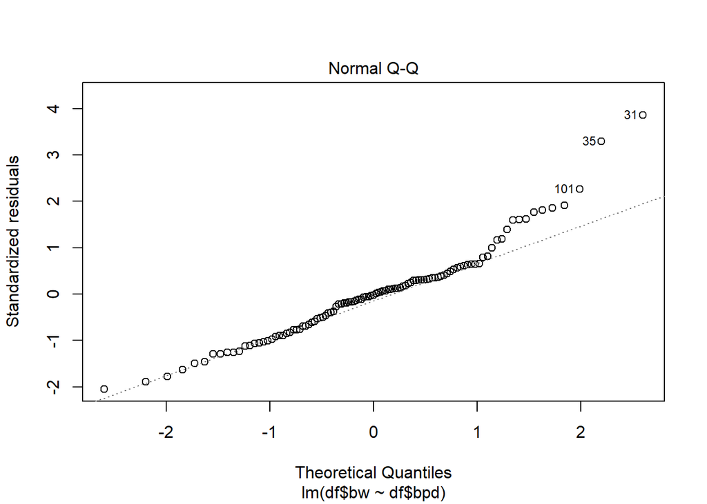

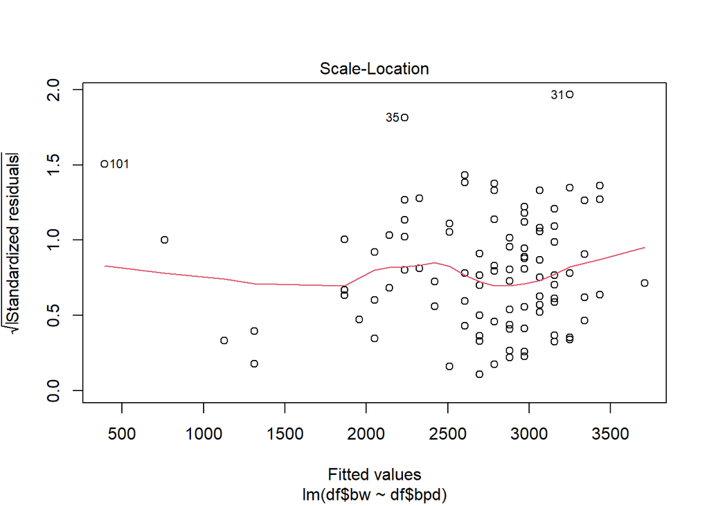

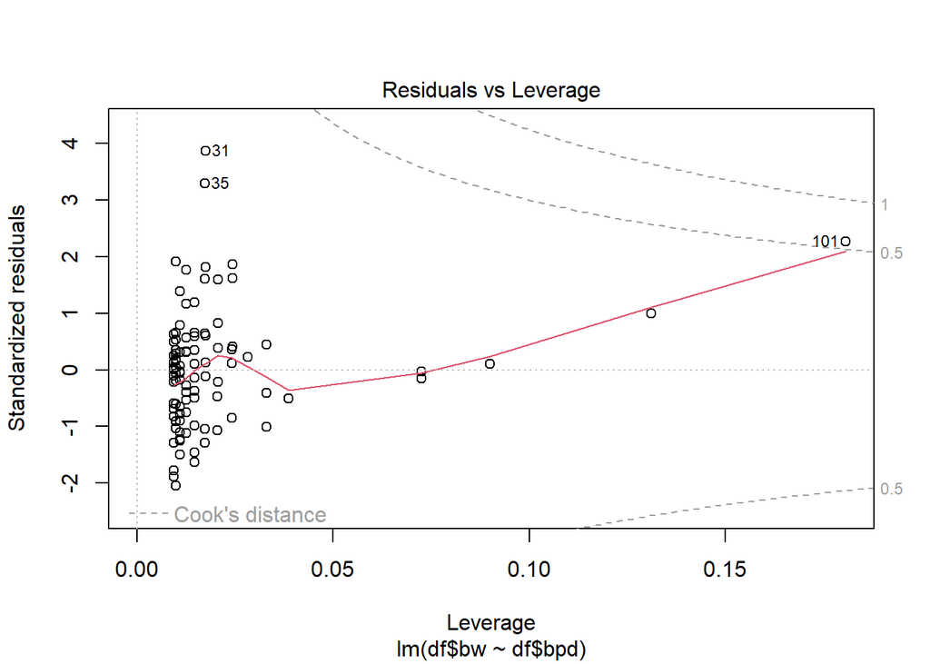

```r
plot(baby.lm)
```

The fit is not ideal. Let’s do the same but taking AD as the explanatory variable:

```r
baby.lm2<-lm(df$bw~df$ad, data=df)
baby.lm2
```

```
##
## Call:
## lm(formula = df$bw ~ df$ad, data = df)
##
## Coefficients:
## (Intercept)        df$ad
##    -2867.92        55.12
```

```r
summary(baby.lm2)
```

```
##
## Call:
## lm(formula = df$bw ~ df$ad, data = df)
##
## Residuals:
##      Min       1Q   Median       3Q      Max
## -1063.57  -199.43    -9.67   153.75  1465.94
##
## Coefficients:
##              Estimate Std. Error t value Pr(>|t|)
## (Intercept) -2867.916    307.346  -9.331 1.94e-15 ***
## df$ad          55.122      3.004  18.347  < 2e-16 ***
## ---
## Signif. codes:  0 '***' 0.001 '**' 0.01 '*' 0.05 '.' 0.1 ' ' 1
##
## Residual standard error: 338.2 on 105 degrees of freedom
## Multiple R-squared:  0.7622, Adjusted R-squared:   0.76
## F-statistic: 336.6 on 1 and 105 DF,  p-value: < 2.2e-16
```

Again, both coefficients (BW and AD) are significant, as their p-values are really small. Also, 0.76 of the variance is explained by the model, which is better than the previous one.

The relationship between the bw and the ad is such that for every increase in ad of 1mm - the bw increases by 55.12g.

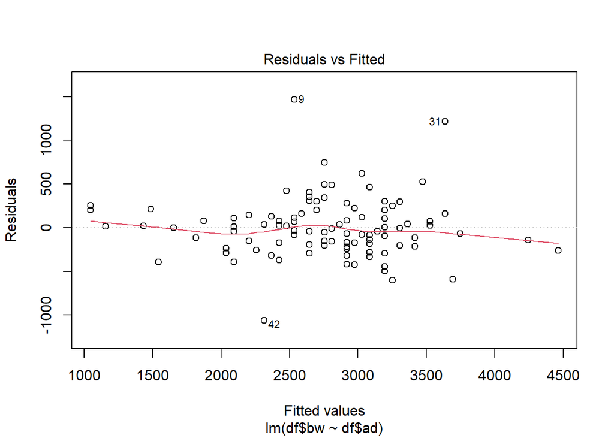

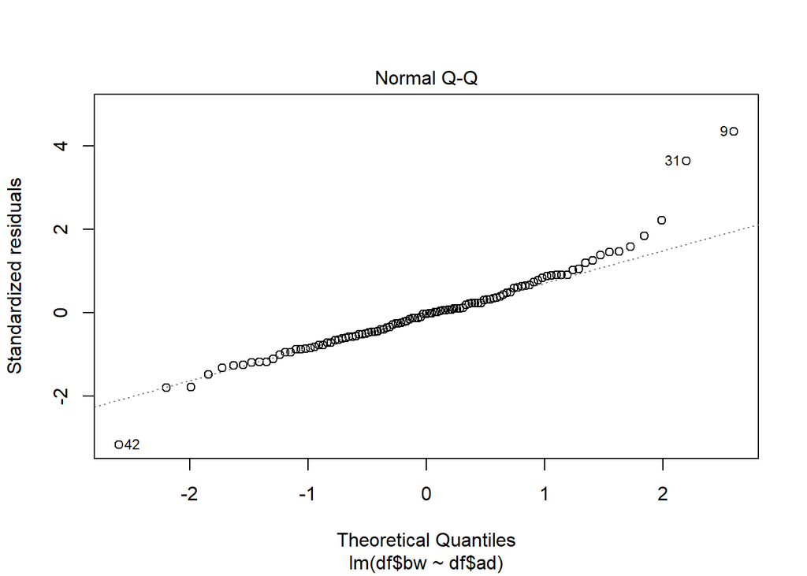

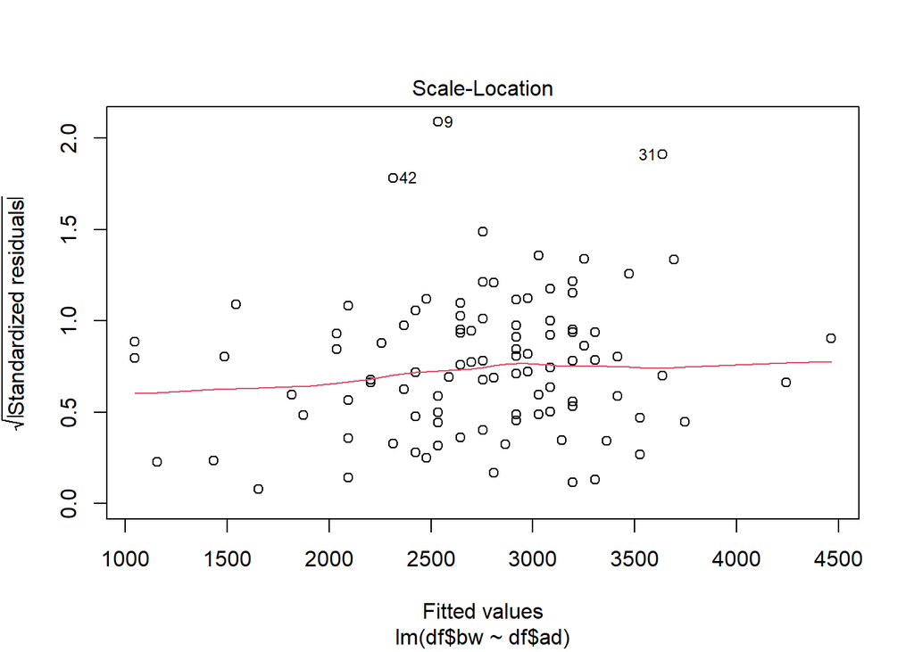

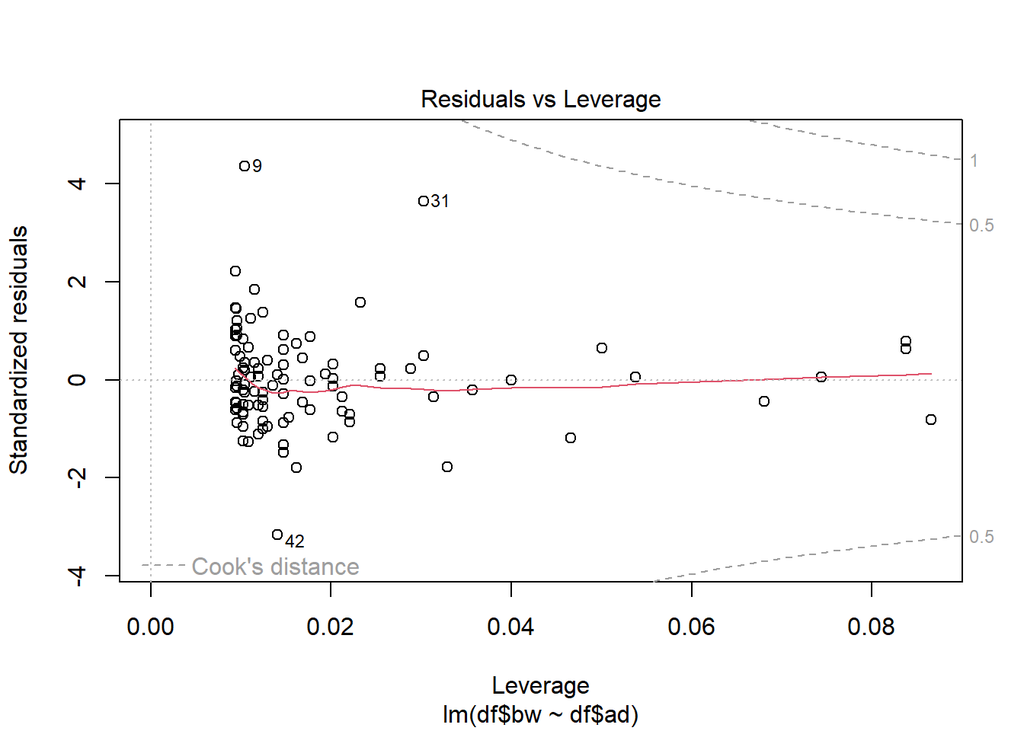

```r
plot(baby.lm2)
```

Therefore, as seen, AD is slightly more accurate at predicting the BW than ADP, not only because of a higher r-squared value, also because of the highest significance of their p-values, as wel as the visual affirmation by looking at both Q-Q plots.

Now, we can try some transformations, to see if we get a better fit:

```r
baby.lm3<-lm(df$bw~df$ad+ I(df$ad^2))
baby.lm3
```

```
##
## Call:
## lm(formula = df$bw ~ df$ad + I(df$ad^2))
##
## Coefficients:
## (Intercept)        df$ad   I(df$ad^2)
##  -3.148e+03    6.083e+01   -2.867e-02
```

```r
summary(baby.lm3)
```

```
##
## Call:
## lm(formula = df$bw ~ df$ad + I(df$ad^2))
##
## Residuals:
##      Min       1Q   Median       3Q      Max
## -1066.24  -201.33   -12.86   151.02  1462.47
##
## Coefficients:
##               Estimate Std. Error t value Pr(>|t|)
## (Intercept) -3.148e+03  1.659e+03  -1.897   0.0605 .
## df$ad        6.083e+01  3.332e+01   1.826   0.0708 .
## I(df$ad^2)  -2.867e-02  1.668e-01  -0.172   0.8638
## ---
## Signif. codes:  0 '***' 0.001 '**' 0.01 '*' 0.05 '.' 0.1 ' ' 1
##
## Residual standard error: 339.8 on 104 degrees of freedom
## Multiple R-squared:  0.7623, Adjusted R-squared:  0.7577
## F-statistic: 166.8 on 2 and 104 DF,  p-value: < 2.2e-16
```

This transformation does not make so much sense to make, and we see we get worse fit.

Finally, we can find estimates based on our model:

$y= -5505.406 + 92.141 \times x$

Let find an estimate for bw when bpd = 80

```r
y.est<- -5505.406 + 92.141*80
y.est
```

```
## [1] 1865.874
```

I would not personally rely on this prediction, as this model does not have that good of a fit.

Now, for:

$y= -2867.916 + 55.122 \times x$

Let find an estimate for y when ad = 105

```r
y.est<- -2867.916 + 55.122*105
y.est
```

```
## [1] 2919.894
```

Finally, we know that the mean birth weight in the UK is 3300g. Let’s check the mean bw of our sample:

```r
mean(df$bw)
```

```
## [1] 2739.093
```

As the bw is normally distributed (seen before), we can perform a t test to check whether there is a significant difference between the sample mean and population mean:

$H_0: \mu=3300$ and $H_1: \mu \ne 3300$

```r
t.test(df$bw, mu=3300, alternative = "two.sided")
```

```
##
##  One Sample t-test
##
## data:  df$bw
## t = -8.405, df = 106, p-value = 2.12e-13
## alternative hypothesis: true mean is not equal to 3300
## 95 percent confidence interval:
##  2606.786 2871.401
## sample estimates:
## mean of x
##  2739.093
```

A seen, the p-value is so small we can confidentally reject the null hypothesis H0 and therefore state that the sample mean and the population mean are not equal.